# Mission 2 — Tester & interpréter

```r
source("../../utils/requirements.R")
library(AmesHousing); set.seed(42); library(dplyr); library(broom)
ames <- make_ames()
idx <- sample(seq_len(nrow(ames)), size = floor(.8*nrow(ames)))
train <- ames[idx,]; test <- ames[-idx,]
mod <- lm(Sale_Price ~ Gr_Liv_Area + Overall_Qual + Year_Built + Full_Bath + Garage_Cars, data=train)
mod_small <- lm(Sale_Price ~ Gr_Liv_Area + Overall_Qual + Year_Built, data=train)
```

## Objectifs

- **Tester** des hypothèses (t-tests sur coefficients, test F global et modèles emboîtés).
- **Intervalles** : construire et **interpréter** des intervalles de confiance (IC) et de **prédiction (IP)**.
- **Évaluer** la **calibration** et la **couverture** des IP sur l’échantillon test.
- **Analyser** l’erreur par sous-groupes (robustesse et équité de base).

## 1) Tests d’hypothèses sur les coefficients

```r
sum_mod <- summary(mod)
sum_mod$coefficients
```

```
                                Estimate   Std. Error    t value      Pr(>|t|)
(Intercept)                -881183.00199 66913.101296 -13.169065  2.967990e-38
Gr_Liv_Area                     56.74416     2.104504  26.963206 1.341430e-139
Overall_QualPoor             23909.61553 20290.439629   1.178369  2.387700e-01
Overall_QualFair             26465.61196 18198.854053   1.454246  1.460128e-01
Overall_QualBelow_Average    38511.36847 17334.313212   2.221684  2.640040e-02
Overall_QualAverage          51976.79659 17211.078719   3.019962  2.555518e-03
Overall_QualAbove_Average    58489.05809 17263.901408   3.387940  7.159023e-04
Overall_QualGood             78020.81605 17366.424861   4.492624  7.378771e-06
Overall_QualVery_Good       120614.34000 17487.957022   6.896994  6.816907e-12
Overall_QualExcellent       199510.31713 17861.122971  11.170088  2.941930e-28
Overall_QualVery_Excellent  242212.29392 18922.086251  12.800507  2.641965e-36
Year_Built                     448.30307    33.296147  13.464112  7.550363e-40
Full_Bath                    -2792.26431  1878.872594  -1.486138  1.373779e-01
Garage_Cars                  13870.75392  1257.341923  11.031807  1.278968e-27
```

**Note**

**Réflexion ciblée :**

- Formulez $H_0$ et $H_1$ pour $\beta_{Year\_Built}$. Interprétez le **t** et la **p-value** au seuil 5%.
- Quelle(s) variable(s) reste(nt) non significative(s)? Les conservez-vous quand même? **Justifiez** (domaine, colinéarité, coût d’erreur, etc.).

## 2) Test global et modèles emboîtés

```r
# F global (déjà dans summary(mod) via statistic)
anova(mod_small, mod)
```

```
Analysis of Variance Table

Model 1: Sale_Price ~ Gr_Liv_Area + Overall_Qual + Year_Built
Model 2: Sale_Price ~ Gr_Liv_Area + Overall_Qual + Year_Built + Full_Bath +
    Garage_Cars
  Res.Df        RSS Df  Sum of Sq      F    Pr(>F)
1   2332 2.8789e+12
2   2330 2.7348e+12  2 1.4413e+11 61.401 < 2.2e-16 ***
---
Signif. codes:  0 '***' 0.001 '**' 0.01 '*' 0.05 '.' 0.1 ' ' 1
```

**Tip**

**À faire (équipe) :**

- Interprétez le test **ANOVA** ci-dessus : le modèle complet apporte-t-il un gain **significatif** par rapport au modèle réduit?
- Calculez et comparez **AIC**/**BIC** pour `mod` et `mod_small`. Quel critère privilégieriez-vous ici et pourquoi?

```r
AIC(mod_small, mod)
```

```
          df      AIC
mod_small 13 55735.13
mod       15 55618.74
```

```r
BIC(mod_small, mod)
```

```
          df      BIC
mod_small 13 55810.00
mod       15 55705.13
```

## 3) Intervalles de confiance et de prédiction

```r
# Moyennes pour les numériques
num_means <- train %>% summarise(
  Gr_Liv_Area = mean(Gr_Liv_Area, na.rm = TRUE),
  Year_Built  = mean(Year_Built,  na.rm = TRUE),
  Full_Bath   = mean(Full_Bath,   na.rm = TRUE),
  Garage_Cars = mean(Garage_Cars, na.rm = TRUE)
)

# Modalité la plus fréquente pour le facteur Overall_Qual
mode_qual <- train %>% summarise(
  Overall_Qual = names(which.max(table(Overall_Qual)))
) %>% mutate(Overall_Qual = factor(Overall_Qual, levels = levels(train$Overall_Qual)))

# Maison type
new0 <- dplyr::bind_cols(num_means, mode_qual)

# IC
predict(mod, newdata = new0, interval = "confidence")
```

```
       fit      lwr      upr
1 160220.6 157199.6 163241.7
```

```r
# IP sur l’échantillon test
pred_pi <- predict(mod, newdata = test, interval = "prediction")
head(pred_pi)
```

```
       fit      lwr      upr
1 180648.2 113338.9 247957.5
2 170506.0 103198.6 237813.3
3 271895.4 204579.2 339211.5
4 405288.4 337646.4 472930.3
5 300636.2 233315.5 367956.8
6 231996.0 164646.9 299345.1
```

**Note**

**Réflexion interprétation :**

- Différence **IC vs IP** : que quantifient-ils, et pourquoi l’IP est-il plus **large**?
- À quoi sert un **IP** pour un décideur (ex. courtier, évaluateur)? Donnez un exemple concret.

## 4) Couverture des IP et calibration

```r
# Taux de couverture 95% des IP sur test
inside <- (test$Sale_Price >= pred_pi[ ,"lwr"]) & (test$Sale_Price <= pred_pi[ ,"upr"])
coverage <- mean(inside)
width <- mean(pred_pi[ ,"upr"] - pred_pi[ ,"lwr"])
knitr::kable(data.frame(Couverture_IP95 = coverage, Largeur_moy_IP = width),
             caption = "Couverture et largeur moyenne des intervalles de prédiction (test)")
```

Couverture et largeur moyenne des intervalles de prédiction (test)

| Couverture_IP95 | Largeur_moy_IP |
| --- | --- |
| 0.9624573 | 134744.5 |

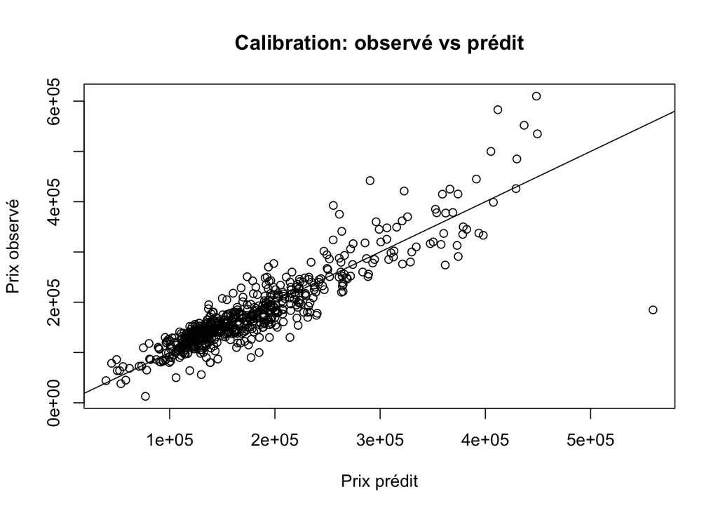

```r
# Plot calibration : observé vs prédit
plot(pred_pi[ ,"fit"], test$Sale_Price,
     xlab = "Prix prédit", ylab = "Prix observé", main = "Calibration: observé vs prédit")
abline(0, 1)
```

**Warning**

**Analyse critique :**

- La **couverture** est-elle proche de 95%? Si non, quelles raisons possibles (mauvaise spécification, hétéroscédasticité, non-normalité, outliers…)?
- La pente de calibration semble-t-elle proche de 1? Y a-t-il **biais systématique** (sous/sur-prédiction)?

## 5) Erreurs par sous-groupes (robustesse)

```r
err <- test$Sale_Price - pred_pi[ ,"fit"]
# Stratification simple : quartiles de surface et niveaux de qualité
q_area <- cut(test$Gr_Liv_Area, breaks = quantile(test$Gr_Liv_Area, probs = seq(0,1,0.25), na.rm=TRUE), include.lowest=TRUE)
by_grp <- test %>% mutate(err = err, q_area = q_area) %>%
  group_by(q_area, Overall_Qual) %>% summarise(MAE = mean(abs(err)), RMSE = sqrt(mean(err^2)), .groups='drop')
knitr::kable(by_grp, caption = "Erreurs par sous-groupes (aire habitable en quartiles × qualité globale)")
```

Erreurs par sous-groupes (aire habitable en quartiles × qualité globale)

| q_area | Overall_Qual | MAE | RMSE |
| --- | --- | --- | --- |
| [520,1.13e+03] | Poor | 30364.570 | 38651.540 |
| [520,1.13e+03] | Fair | 13414.979 | 17555.484 |
| [520,1.13e+03] | Below_Average | 13564.462 | 18418.238 |
| [520,1.13e+03] | Average | 13883.661 | 17991.222 |
| [520,1.13e+03] | Above_Average | 13903.862 | 17361.991 |
| [520,1.13e+03] | Good | 20736.199 | 21570.278 |
| (1.13e+03,1.42e+03] | Fair | 16939.169 | 19902.571 |
| (1.13e+03,1.42e+03] | Below_Average | 21017.884 | 24903.919 |
| (1.13e+03,1.42e+03] | Average | 13765.626 | 17648.594 |
| (1.13e+03,1.42e+03] | Above_Average | 14439.528 | 17670.036 |
| (1.13e+03,1.42e+03] | Good | 14201.040 | 17231.101 |
| (1.13e+03,1.42e+03] | Very_Good | 31862.465 | 37032.937 |
| (1.42e+03,1.72e+03] | Below_Average | 33394.954 | 39938.912 |
| (1.42e+03,1.72e+03] | Average | 21226.006 | 27886.582 |
| (1.42e+03,1.72e+03] | Above_Average | 16698.841 | 24631.618 |
| (1.42e+03,1.72e+03] | Good | 23702.029 | 29274.231 |
| (1.42e+03,1.72e+03] | Very_Good | 29526.155 | 41360.485 |
| (1.42e+03,1.72e+03] | Excellent | 32939.308 | 33972.903 |
| (1.72e+03,4.68e+03] | Fair | 2609.718 | 2609.718 |
| (1.72e+03,4.68e+03] | Below_Average | 58601.132 | 58601.456 |
| (1.72e+03,4.68e+03] | Average | 30841.210 | 39331.843 |
| (1.72e+03,4.68e+03] | Above_Average | 24321.604 | 30690.056 |
| (1.72e+03,4.68e+03] | Good | 28348.812 | 35079.171 |
| (1.72e+03,4.68e+03] | Very_Good | 37801.170 | 50260.929 |
| (1.72e+03,4.68e+03] | Excellent | 52026.385 | 63023.133 |
| (1.72e+03,4.68e+03] | Very_Excellent | 132702.685 | 178022.285 |

**Note**

**Question d’enquête :**

- Identifiez **un** sous-groupe avec une erreur nettement plus élevée. Donnez **une hypothèse** explicative (non-linéarité, interaction manquante, variable omise…).
- Proposez **une action** concrète (transformation, terme quadratique, interaction, variable additionnelle) pour la Mission 3.

## 6) Comparaison de modèles

```r
# Performance globale simple (pour mémoire) :
pred <- pred_pi[ ,"fit"]
rmse <- sqrt(mean((pred - test$Sale_Price)^2))
mae  <- mean(abs(pred - test$Sale_Price))
knitr::kable(data.frame(Model=c("Complet","Simple"),
                        RMSE=c(rmse, sqrt(mean((predict(mod_small, test) - test$Sale_Price)^2))),
                        MAE =c(mae,  mean(abs(predict(mod_small, test) - test$Sale_Price)))),
             caption = "Comparaison rapide de performance (test)")
```

Comparaison rapide de performance (test)

| Model | RMSE | MAE |
| --- | --- | --- |
| Complet | 34713.31 | 22622.28 |
| Simple | 35150.98 | 23088.00 |

**Tip**

**Décision modèle :**

- Utilisez **ANOVA + AIC/BIC + calibration/couverture** (pas seulement RMSE/MAE) pour trancher entre `mod` et `mod_small`. Justifiez la **traçabilité** de votre choix.

## Questions

- Q1. Testez $H_0\!:\;\beta_{Year\_Built}=0$ (5%). Concluez et **interprétez** dans le contexte.
- Q2. Le test **ANOVA** conclut-il à un apport significatif de `Full_Bath` et `Garage_Cars` pris ensemble? Décision?
- Q3. La **couverture** empirique des IP95 est-elle satisfaisante? Si non, quelle **modification** du modèle proposeriez-vous?
- Q4. Identifiez un **sous-groupe** à erreur élevée et proposez une **amélioration**.

## Pour aller plus loin

- Calculez un **IC** pour la moyenne conditionnelle d’une maison type (définissez explicitement la maison) et **expliquez** la différence avec un **IP** pour cette même maison.
- Montrez un **exemple** où AIC préfère `mod` mais BIC préfère `mod_small`. Laquelle des deux décisions retiendriez-vous ici et pourquoi (taille d’échantillon, parcimonie, objectif)?
- Implémentez une **validation croisée K-fold** *maison* (sans nouveaux packages) et comparez RMSE moyen de `mod` vs `mod_small`.